# Northern Three Spatial Analyses (Habitat: Riparian Vegetation)

- Show All Code
- Hide All Code
- View Source

Author

Adam Shand

Published

May 27, 2024

**R Version**

For R session info at the time of rendering this script see Section 6.

# 1 Introduction

This script contains the methods used to wrangle, analyse and present both freshwater and estuarine riparian vegetation data in the Northern Three regions. The data used in this script is subset of the Regional Ecosystems (RE) dataset. For a guide on downloading RE data refer to the README document for the Spatial Analysis GitHub repo.

**Note**

The results for the riparian vegetation script are currently used within the freshwater habitat and hydrology section, and the estuarine habitat section of the technical report. The amount of riparian vegetation lost/gained is the metric assessed.

The main objectives of this script are to:

- Define vegetation that is classified as in the “riparian” area.
- Select only this data.
- Calculate the total amount of freshwater riparian coverage.
- Calculate the total amount of estuarine riparian coverage.
- Create a tabular summary of the coverage.
- Create maps of the coverage.
- Create plots of the coverage and coverage change.

# 2 Script Set Up

This script requires multiple core spatial packages, all packages are loaded below.

```r
library(sf)
library(tmap)
library(grid)
library(glue)
library(here)
library(tidyverse)
library(ggallin)
```

We also need to set up key variables for the script such as where we are going to save the outputs, and what coordinate reference system (crs) we are going to be using. Note that the crs is first established under ‘params’ at the start of the script.

A side note here, because data is not updated every year, even when we create a new folder under a new financial year does not necessarily mean that there will be new results. E.g. the years of regional ecosystem data we have are currently pre_clear, 1997, 1999, 2000, 2001, 2003, 2005, 2006, 2006b, 2007, 2009, 2011, 2013, 2015, 2017, 2019, and 2021. So if we were to put financial year 2001 or financial year 2002 we would still get the same results.

To make matters worse, the year of data (e.g. 2021) is not released on that same year, but at a later date. Specifically, the 2021 data was released in late 2023.

Thus instead of trying to name folders with just the financial years we will name folders with financial years and data layer years using a translation as follows:

fyear = 2023, data layer = 2021 fyear = 2022/21 data layer = 2019 fyear = 2020/19, data layer = 2017 fyear = 2018/17, data layer = 2015 fyear = 2016/15, data layer = 2013

```r
#get the targeted financial year that was set in the yaml
current_fyear <- params$target_fyear

#get the data year that we should look at using this relationship
data_year <- ifelse(current_fyear %in% c(2023), 2021,
                    ifelse(current_fyear %in% c(2022, 2021), 2019,
                           ifelse(current_fyear %in% c(2020, 2019), 2017,
                                  ifelse(current_fyear %in% c(2018, 2017), 2015,
                                         ifelse(current_fyear %in% c(2016, 2015), 2013)))))

#we also need to figure out what the most recent previous dataset is - this is useful later on (we dont need to bother going super far back)
prev_data_year <- ifelse(data_year == 2021, 2019,
                         ifelse(data_year == 2019, 2017,
                                ifelse(data_year == 2017, 2015,
                                       ifelse(data_year == 2015, 2013))))
```

```r
#set project variables: crs factor and current_fyear
proj_crs <- params$project_crs

#format the date for the path below and to be used as a variable in naming later
date <- format(Sys.time(), "%Y-%m-%d")

#create a file path to help with saving things
save_path <- here(glue("outputs/n3_habitat_riparian-vegetation/fyear-{current_fyear}_data-{data_year}/"))

#bring that path to life
dir.create(save_path)

#create an extra off of this for maps and plots
dir.create(glue("{save_path}/maps/"))
dir.create(glue("{save_path}/plots/"))

#turn off spherical geometry
sf_use_s2(F)

#turn off scientific notation
options(scipen = 999)
```

# 3 Load Data

Now the script is set up we need to load in all of the required datasets. This will be broken into two segments: - Spatial data specific to the N3 region - such as the region, basin, and sub basin boundaries. - Riparian boundaries and the Regional Ecosystem (riparian) data.

## 3.1 Spatial Data

Spatial data for the northern three regions should be readily available in the repo, the dataset is created by the n3_region-builder.qmd script in the repo that should be the first script run for new users. If the dataset is not available refer back to the README document in the GitHub repo. The other parts of spatial data here should go off without a hitch if the region-builder script has been run.

```r
#read in the northern three spatial files and reduce down to only the components we need
n3_region <- st_read(here("data/n3_region-builder/n3_region.gpkg")) |>
  filter(environment != "Marine") |>
  group_by(region, environment, basin_or_zone, sub_basin_or_sub_zone) |> summarise(geom = st_union(geom)) |>
  rename(basin = basin_or_zone, sub_basin = sub_basin_or_sub_zone) |> ungroup() |>
  st_cast() |> st_make_valid()

#load a Queensland outline from the aims package
qld <- get(data("gbr_feat", package = "gisaimsr")) |> filter(FEAT_NAME %in% c("Mainland", "Island")) |>
  st_transform(proj_crs)
```

## 3.2 Riparian Boundaries and Riparian Data (RE data)

The dataset previously used (pre 2021) to define the riparian boundaries is a bit vague and has never really been properly identified. Here we will be using the watercourse lines and statewide corridors datasets. Please refer to [Issue 49](https://github.com/Northern-3/spatial-analyses/issues/49) on the GitHub repo for more info.

The vegetation dataset used in this analysis is the Regional Ecosystems dataset that is used by multiple scripts in the n3_habitat space.

**Note**

This section of the code takes a significant chunk of time to run. Processes have been put in place to reduce the need to rerun this step, however the inclusion of any new regional ecosystem layers as they are published will need to be run through this step.

**Note**

Only the newest and oldest RE layers are provided by QSpatial. If middle layers are missing, refer to README regarding download all layers. Note that the middle layers are not necessarily required for the script to run, but certain outputs benefit from the inclusion of additional layers.

Regional Ecosystem (RE) data (i.e. vegetation) is published to QSpatial by DES and covers the entirety of Queensland (for more info go [here](https://www.qld.gov.au/environment/plants-animals/plants/ecosystems/descriptions)). Vegetation type is given via an RE code such as “11.1.3” where:

- 11 = bioregion (e.g. The Brigalow Belt).
- 1 = landzone (e.g. Tidal flats and beaches).
- 3 = vegetation community (e.g. Sedgelands on marine clay plains).

Regional Ecosystem data is used by multiple multiple scripts under the “habitat” banner in this repo, and is therefore stored in the generic “n3_habitat” data folder. Unfortunately, the custom function `n3_habitat_data()` is not completely applicable in this script due to the complexity of the area selected (see [issue 53](https://github.com/Northern-3/spatial-analyses/issues/53) for more info). Instead pieces of the custom function have been pulled out and new parts added. Given that this new version is only going to be used by one script it doesn’t warrant the creation of an entirely new function and instead is all written in the code chunks below. This code chunk will still work in tandem, before, or after the original `n3_habitat_data()` function[^1]. Please note that it will also work for any number of RE layers, however, this means that for n number of layers in the folder, n number of datasets will always be loaded. This can reduce speed, particularly if you are only interested in the first and layer years. An overview of what we are going to do below is as follows:

- Check if the riparian boundary data has been created, if it does load it, if it doesn’t create it. **Takes a long time.**
- Check if riparian cropped RE datasets exists, if they do move on,
- If they don’t, check if N3 cropped RE datasets exists, if they do, load them and create the riparian cropped RE datasets, **Takes a long time.**
- If they don’t load the original RE data, and create both the N3 and riparian cropped RE datasets. **Takes a long time.**

After each riparian cropped RE datasets has been made, we also perform some additional calculations before saving the final output, these include:

- Grouping vegetation types into remnant, non-remnant and other, **Takes a long time.**
- Calculating the total area in km2 of each vegetation group, **Takes a long time.**
- Merging all polygons in the same vegetation group to improve visual clarity, **Takes a long time.**
- Extracting all non-spatial information into one centralized table. **Takes a long time.**

First we will check/create the riparian area dataset.

```r
#create path to the northern three riparian area dataset
rip_path <- here("data/n3_habitat_riparian-vegetation/riparian_area/n3_riparian_boundaries.gpkg")

if (file.exists(rip_path)){ #if the riparian area dataset exists, read it in

  rip_boundaries <- st_read(rip_path)

} else { #otherwise create and save the dataset

  #read in watercourse lines and drop all rows with strm_order == NA or 1, crop to the n3 region
  n3_wc_lines <- st_read(here("data/n3_habitat_riparian-vegetation/riparian_area/watercourse_lines.gpkg")) |>
    st_transform(proj_crs) |> filter(!is.na(STRM_ORDER)) |>
    st_intersection(n3_region) |>
    select(region, environment, basin, sub_basin, Shape) |>
    rename(geom = Shape)

  #read in the statewide corridors and filter for only the riparian layer
  n3_corridors <- st_read(here("data/n3_habitat_riparian-vegetation/riparian_area/riparian_corridors.gdb"),
                          layer = st_layers(here("data/n3_habitat_riparian-vegetation/riparian_area/riparian_corridors.gdb"))[[1]]) |>
    st_transform(proj_crs) |>
    st_intersection(n3_region) |>
    select(region, environment, basin, sub_basin, Shape) |>
    rename(geom = Shape)

  #combine datasets
  rip_boundaries <- rbind(n3_wc_lines, n3_corridors)

  #project data to a meters dataset, add the 50m buffer, project back to GDA2020
  rip_boundaries <- st_transform(rip_boundaries, "EPSG:7855") |> st_buffer(50) |> st_transform(proj_crs)

  #save to file
  st_write(rip_boundaries, rip_path, append = F)

  #clean up and force gc
  rm(n3_wc_lines, n3_corridors)
  gc()

}

rm(rip_path)
```

Then we will check/create the re_riparian_datasets.

```r
#create paths to different versions of the re data
raw_path <- here("data/n3_habitat/re_raw/")
cropped_path <- here("data/n3_habitat_riparian-vegetation/re_riparian_cropped/")

#get a vector of all the original files in the raw folder that contain ".gpkg"
file_vec <- tools::file_path_sans_ext(list.files(raw_path, pattern = ".gpkg"))

#create a table to hold non spatial version
re_rip_tbl_raw_data <- data.frame()

if (file.exists(glue("{cropped_path}/re_rip_table.csv"))){#if the csv exists, open and check if years match the number of years available

  re_rip_tbl_raw_data <- read_csv(glue("{cropped_path}/re_rip_table.csv"))

  if (length(unique(re_rip_tbl_raw_data$year)) < length(file_vec)){#if years in csv are not equal or greater, create update flag for below

    update_csv <- TRUE

    re_rip_tbl_raw_data <- data.frame()

    } else {update_csv <- FALSE}

} else {update_csv <- TRUE} #if the csv does exist at all, of course it will also need to be "updated"

for (i in file_vec){#for each file in the vector or original files

  if (file.exists(glue("{cropped_path}/{i}_riparian_cropped.gpkg"))){#if the fully riparian cropped version of the file exists

    if (update_csv){#if the csv requires updating

      temp <- st_read(glue("{cropped_path}/{i}_riparian_cropped.gpkg"))
      temp <- temp |> st_drop_geometry()
      re_rip_tbl_raw_data <- rbind(re_rip_tbl_raw_data, temp)

      #save the dataset
      write_csv(re_rip_tbl_raw_data, glue("{cropped_path}/re_rip_table.csv"), append = F)

    } #otherwise do nothing

  } else { #if no cropped version of the original data exists

    #create a lookup to catch any cols named Shape
    lookup <- c(geom = "Shape")

    #read in the original regional ecosystem layer and rename any shape columns
    re_layer <- st_read(glue("{raw_path}/{i}.gpkg")) |> rename(any_of(lookup))

    #and separate the data into "standard" geometries - polygons, and non-standard geometries - e.g. multisurfaces
    standard_geoms <- re_layer |> filter(grepl("POLYGON", st_geometry_type(geom))) |> st_make_valid()
    non_standard_geoms <- re_layer |> filter(grepl("MULTISURFACE", st_geometry_type(geom)))

    #save non-standard geoms to be edited
    st_write(non_standard_geoms, glue("{cropped_path}/temporary_storage.gpkg"), delete_dsn = T)

    #use the gdalUtilies to open edit and save the file (it auto saves as a folder containing a shapefile)
    gdalUtilities::ogr2ogr(glue("{cropped_path}/temporary_storage.gpkg"), glue("{cropped_path}/temporary_storage"),
                           explodecollections = T, nlt = 'CONVERT_TO_LINEAR', overwrite = T)

    #create a second lookup to catch any cols named Shape
    lookup_2 <- c(Shape_Length = "Shape_Leng")

    #read back in the edited file
    fixed_geoms <- st_read(glue("{cropped_path}/temporary_storage/temporary_storage.shp")) |>
      rename(geom = geometry) |> st_make_valid() |> rename(any_of(lookup_2))

    #join the fixed data onto the standard data
    re_layer <- rbind(standard_geoms, fixed_geoms)

    #transform the crs, then intersect over the bvg area
    re_layer <- re_layer |> st_transform(proj_crs) |> st_intersection(n3_region)

    #get a vector of all the basins present in the data
    basin_vector <- unique(n3_region$basin)

    #create a vector to track all the files that are created
    rip_basin_files <- c()

    for (j in basin_vector){#for each basin

      #filter for only that basin of RE data and take only polygons
      re_basin_layer <- re_layer |> filter(basin == j) |> st_collection_extract("POLYGON")

      #filter for only that basin of riparian boundaries then drop all columns except environment
      rip_basin_boundaries <- rip_boundaries |> filter(basin == j) |> select(environment)

      #intersect over the pair, calculate the area
      re_rip_basin_layer <- re_basin_layer |> st_intersection(rip_basin_boundaries) |> mutate(area = st_area(geom))

      #get a vector of "vegetation" types that aren't vegetation
      non_veg_types <- str_subset(unique(re_rip_basin_layer$RE1), "^[A-Za-z]")

      #assign vegetation types and group
      re_rip_basin_layer <- re_rip_basin_layer |>
        mutate(vegetation = case_when(!RE1 %in% non_veg_types ~ "Remnant Vegetation", T ~ RE1)) |>
        select(region, environment, basin, sub_basin, vegetation, area)

      #change the "vegetation" types, water, shallow, estuary, and ocean, to simply water
      re_rip_basin_layer <- re_rip_basin_layer |>
        mutate(vegetation = case_when(str_detect(vegetation, "estuary|water|shallow|ocean") ~ "Water",
                                      str_detect(vegetation, "non") ~ "Non-Remnant Vegetation",
                                      str_detect(vegetation, "plantation") ~ "Plantation",
                                      T ~ vegetation))

      #keep track of the data that has been created
      rip_basin_files <- append(rip_basin_files, j)

      #assign each dataset to the global environment
      assign(j, re_rip_basin_layer)

    }

    #create a list containing all of the basin datasets that were loaded in
    basin_rip_list <- lapply(rip_basin_files, function(x) get(x))

    #bind all datasets together
    re_rip_data <- do.call(rbind, basin_rip_list)

    #clean up
    rm(list = rip_basin_files)

    #pull the year from the name
    i_year <- str_remove_all(i, "^re_|_v12_2")

    #add year column to data
    re_rip_data <- re_rip_data |> mutate(year = i_year)

    #update units to be km2
    re_rip_data$area <- units::set_units(re_rip_data$area, km^2)

    #save the final rip cropped file with spatial data still attached
    st_write(re_rip_data, glue("{cropped_path}/{i}_riparian_cropped.gpkg"), append = F)

    #drop spatial data
    re_rip_data <- re_rip_data |> st_drop_geometry()

    #bind to main dataset
    re_rip_tbl_raw_data <- rbind(re_rip_tbl_raw_data, re_rip_data)

    #clean up
    rm(rip_basin_files,  re_layer, re_basin_layer, rip_basin_boundaries, re_rip_basin_layer,
       non_veg_types, basin_rip_list, re_rip_data, i_year, basin_vector, lookup)
    unlink(glue("{cropped_path}/temporary_storage.gpkg"))
    unlink(glue("{cropped_path}/temporary_storage"), recursive = T)

    #save the dataset
    write_csv(re_rip_tbl_raw_data, glue("{cropped_path}/re_rip_table.csv"), append = F)

  }

}

#clean up
rm(cropped_path, file_vec, raw_path, update_csv)
```

Once this heavy work has been completed you should now be able to see all of the regional ecosystem - riparian cropped datasets in the relevant folder, as well as a csv summarizing all non spatial aspects. Note that while the csv will be loaded into the global environment, each of the spatial datasets will remain unloaded in the data folder. This is because the cropped datasets are still too large to all be loaded into memory at the same time. Moving forward, wherever possible we will be using the csv version to calculate answers.

# 4 Analyse Data

Currently we are looking to calculate:

- The total area coverage by each vegetation in each basin for each year (which was already completed above).
- The proportion of the total area that each vegetation covers (relative to the total riparian area).
- The change year on year of each vegetation.

## 4.1 Calculate Total Vegetation Coverage and Proportional Coverage

Here we group up, calculate total coverage, and then use row wise to divide by each vegetation type.

```r
#calculate the total area of each sub basin for each year and the proportion each vegetation covers
re_rip_tbl_data <- re_rip_tbl_raw_data |>
  group_by(region, environment, basin, sub_basin, year) |> mutate(total_surveyed_area = sum(area)) |>
  ungroup() |>
  rowwise() |> mutate(veg_percent_of_total_area = as.numeric((area/total_surveyed_area)*100)) |>
  ungroup() |>
  group_by(region, environment, basin, sub_basin, year, total_surveyed_area, vegetation) |>
  summarise(area = sum(area), veg_percent_of_total_area = sum(veg_percent_of_total_area)) |>
  ungroup()

#are all basins represented in sub basins?
if(!all(unique(unique(re_rip_tbl_data$basin) %in% unique(re_rip_tbl_data$sub_basin)))){#if not:

  #create basin version
  basin_temp_tbl <- re_rip_tbl_data |> filter(basin != sub_basin) |>
    group_by(region, environment, basin, year, vegetation) |>
    summarise(total_surveyed_area = sum(total_surveyed_area),
              area = sum(area),
              veg_percent_of_total_area = as.numeric((area/total_surveyed_area)*100)) |>
    ungroup() |>
    mutate(sub_basin = basin)

  #bind together
  re_rip_tbl_data <- rbind(re_rip_tbl_data, basin_temp_tbl)

}

#clean up
rm(basin_temp_tbl)
```

## 4.2 Calculate Year on Year Change

After calculating the area each vegetation types covers (and had previously covered) we can then do a year on year comparison to track the loss/gain over time. A good trick here is to order by vegetation type, so we can then use the lag() function to query the above row.

```r
#create a set of rows for non remnant vegetation in the pre clear year (this is obviously 0 but helps with calculations below)
non_rem_tbl <- re_rip_tbl_data |> filter(year == "pre_clear", vegetation == "Remnant Vegetation") |>
  mutate(area = 0, veg_percent_of_total_area = 0, vegetation = "Non-Remnant Vegetation")

#bind these new rows to the main data
re_rip_tbl_data <- bind_rows(re_rip_tbl_data, non_rem_tbl)

#update units (units are missing on repeat runs of the same script)
re_rip_tbl_data$area <- units::set_units(re_rip_tbl_data$area, km^2)

#create a 0 value with units
replace_value <- units::set_units(0, km^2)

#order by RE type, group by basin and RE, then compare the row to the one above using lag(), replace na values with 0
re_rip_tbl_data <- re_rip_tbl_data |> arrange(environment, sub_basin, vegetation, year) |>
  group_by(environment, basin, sub_basin, vegetation) |>
  mutate(y_on_y_veg_area_change = area - lag(area),
         y_on_y_veg_percent_change = (y_on_y_veg_area_change/lag(area))*100) |>
  mutate(across(matches("percent"), \(x) as.vector(x)),
         across(matches("percent"), \(x) replace_na(x, 0)),
         across(matches("area"), \(x) replace_na(x, replace_value)),
         across(where(is.numeric), \(x) round(x, 5))) |>
  ungroup()

#fix up erraneous percent change values (anything over 100% change gets a score of 100)
re_rip_tbl_data <- re_rip_tbl_data |>
  mutate(y_on_y_veg_percent_change = case_when(abs(y_on_y_veg_percent_change) > 100 ~ 100,
                                               T ~ y_on_y_veg_percent_change))
```

## 4.3 Calculate Standardised Scores

We can then use the percent change year on year to calculate the standardised scores for each vegetation type

```r
standardised_riparian <- function (x){

  if (x > 0){floor(100-abs(19-((abs(x)-0)*(19/99.9))))}
  else if (x >= -0.1){floor(61+abs(19.9-((abs(x)-0)*(19.9/0.1))))}
  else if (x >= -0.5){floor(41+abs(19.9-((abs(x)-0.11)*(19.9/0.39))))}
  else if (x >= -1){floor(21+abs(19.9-((abs(x)-0.51)*(19.9/0.49))))}
  else if (x < -1){floor(abs(20.9-((abs(x)-1.01)*(20.9/98.99))))}
}


re_rip_tbl_data <- re_rip_tbl_data |>
  rowwise() |>
  mutate(standardised_score = standardised_riparian(y_on_y_veg_percent_change)) |>
  ungroup()
```

Once that is done we can save the full table to the outputs folder.

```r
#create a new version just to update values to ha instead of km2
save_version <- re_rip_tbl_data |>
  mutate(area = round(area*100, 1),
         y_on_y_veg_area_change = round(y_on_y_veg_area_change*100, 1),
         y_on_y_veg_percent_change = round(y_on_y_veg_percent_change, 2))

#save full table
write_csv(save_version, glue("{save_path}/riparian-vegetation_full_table.csv"))

#edit cells of year column then pivot data for a clean presentation for the freshwater and estuarine environments (separately)
report_ready <- save_version |>
  mutate(year = str_remove(year, "remnant_"),
         year = case_when(is.na(year) ~ "pre_clear",
                          T ~ year)) |>
  select(!c(total_surveyed_area, veg_percent_of_total_area)) |>
  filter(vegetation == "Remnant Vegetation") |>
  rename(area_change = y_on_y_veg_area_change,
         percent_change = y_on_y_veg_percent_change) |>
  mutate(standardised_score = case_when(year == data_year ~ standardised_score,
                                        T ~ NA)) |>
  pivot_wider(names_from = year, values_from = c(area, area_change, percent_change))

#compress the table
report_ready <- report_ready |>
  group_by(environment, sub_basin) |>
  mutate(across(6:ncol(report_ready)-2, ~sum(.x, na.rm = T))) |>
  ungroup() |>
  unique()

#create custom variables for column selection
cols_to_select <- c(glue("area_{prev_data_year}"), glue("area_{data_year}"), glue("change_{data_year}"))

#select oldest and two most recent years of data for area, and only most recent for change
report_ready <- report_ready |>
  select(region, basin, sub_basin, environment, area_pre_clear, matches(cols_to_select), standardised_score)

#create fw and est versions
fw_report_ready <- report_ready |>
  filter(environment == "Freshwater")
est_report_ready <- report_ready |>
  filter(environment == "Estuarine")

#load in our custom colouring function
source(here("functions/cond_form_rc_grades.R"))

#run function, noting to specify which colour system we want to use
cond_form_rc_grades(fw_report_ready, glue("{save_path}/fw_riparian_vegetation_report_table"),
                          cols = ncol(fw_report_ready), method = "Numeric")

#run function, noting to specify which colour system we want to use
cond_form_rc_grades(est_report_ready, glue("{save_path}/est_riparian_vegetation_report_table"),
                          cols = ncol(report_ready), method = "Numeric")

#clean up
rm(save_version)
```

# 5 Visualise Data

Now on to the fun stuff - visualizations. Below we are looking to present the data in a few different ways, by:

## 5.1 Streamline data

Before we can visualise we need to streamline our tbl data to remove some of the excessive rows that were created to calculate final scores.

```r
#drop rows that we don't need
re_rip_tbl_data <- re_rip_tbl_data |>
  filter(!(region == "Dry Tropics" & basin == sub_basin))
```

## 5.2 Horizontal Stacked Bar Chart

The horizontal stacked bar chart will make use of the table version of the data as there is no spatial information required. First we will create a custom palette that ggplot will use as a reference for how to color groups.

```r
#create custom palette
my_tbl_palette <- c("#B83D00", "#8C3FC5", "#B8E08C", "#75DBFF")

#assign names to my palette so ggplot can colour everything correctly
names(my_tbl_palette) <- sort(unique(re_rip_tbl_data$vegetation))
```

```r
#list out basins
#sub_basins <- unique(n3_region$sub_basin)

#list out basins
basins <- unique(n3_region$basin)

#list out enviros
enviros_to_loop <- unique(n3_region$environment)

#get the newest year
#target_year <- tail(sort(unique(re_rip_tbl_data$year)),1)

for (i in basins){#for each basin
  for (j in enviros_to_loop){#for each environment

    #select a specific basin and arrange the data appropriately
    basin_plot <- re_rip_tbl_data |> filter(basin == i, year == glue("remnant_{data_year}"), environment == j) |>
      arrange(desc(veg_percent_of_total_area)) |>
      mutate(vegetation = factor(vegetation, levels = unique(vegetation)))

    if (nrow(basin_plot) != 0){

      #create a plot
      plot <- ggplot(basin_plot, aes(fill = vegetation, x = basin, y = veg_percent_of_total_area)) +
        geom_bar(position = position_fill(reverse = T), stat = "identity") +
        scale_fill_manual(values = my_tbl_palette) +
        scale_x_discrete(expand = c(0.025, 0)) +
        scale_y_continuous(expand = c(0, 0), labels = scales::percent_format(accuracy = 1)) + #, breaks =
        labs(x = "", y = "", fill = glue("{i} {j}\nRiparian Vegetation")) +
        theme(axis.text.x = element_text(colour = "black"),
              axis.text.y = element_blank(),
              axis.line.x = element_line(colour = "black"),
              axis.ticks.length = unit(-0.15, "cm"),
              panel.background = element_blank()) +
        coord_flip()

      #edit names
      edit_i <- str_remove_all(str_to_lower(paste(i, data_year, sep = "_")), "_tbl")
      edit_j <- str_to_lower(j)

      #save
      ggsave(glue("{save_path}/plots/{edit_i}_{edit_j}_riparian_vegetation_plot.png"), plot, width = 12, height = 4)
    }
  }
}
```

Here is an example of how one of the plots looks, noting that the actual outputted version looks much nicer.

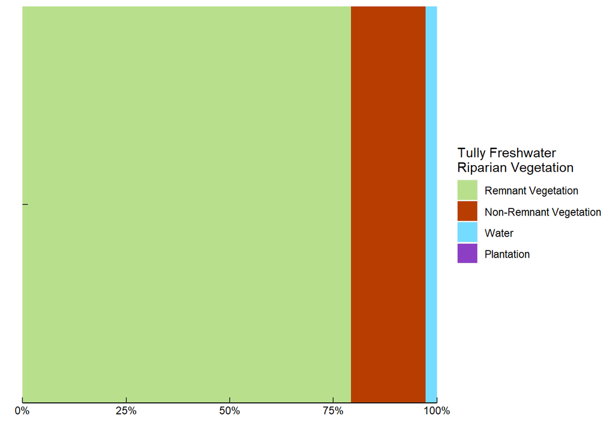

```r
plot
```

## 5.3 Map Riparian Vegetation

As noted previously, no spatial datasets are currently in the global environment, so will have to load the target one now.

```r
#read in target data layer
re_rip_map_data <- st_read(here(glue("data/n3_habitat_riparian-vegetation/re_riparian_cropped/re_remnant_{data_year}_v12_2_riparian_cropped.gpkg")))
```

Then we need to a colour scheme to the data for the map to reference. We do this by creating a name variable for all colours.

```r
#add an empty column to hold palette: non-remnant, plantation, remnant, water
my_map_palette <- c("#B83D00", "#8C3FC5", "#B8E08C", "#75DBFF")

#assign names to my palette so ggplot can colour everything correctly
names(my_map_palette) <- sort(unique(re_rip_map_data$vegetation))
```

Then match the colours to the appropriate columns.

```r
#add an empty column to hold palette
re_rip_map_data$palette <- NA

for (i in 1:length(my_map_palette)){#for the length of the palette, match each element

  #using the custom palette we created earlier
  re_rip_map_data <- re_rip_map_data |>
    mutate(palette = case_when(vegetation == names(my_map_palette)[i] ~ my_map_palette[[i]],
                               T ~ palette))
}
```

Then we will create the maps, looping over each basin and swapping between each environment.

```r
#remove environments out of the n3 region dataset (just creates unnecessary clutter)
n3_region <- n3_region |>
  group_by(region, basin, sub_basin) |> summarise(geom = st_union(geom)) |>
  ungroup() |> st_cast() |> st_make_valid()

#list out basins
basins <- unique(n3_region$sub_basin)

#list out environments
enviros_to_loop <- unique(re_rip_map_data$environment)

#note we are using the target_year variable created earlier
for (i in unique(re_rip_map_data$environment)){ #for each environment
  for (j in unique(n3_region$region)){ #for each region

    #select region
    target_region <- re_rip_map_data |> filter(region == j, environment == i)

    #get the region outline
    region_outline <- n3_region |> filter(region == j)

    #create a bbox of the vegetation data
    reg_veg_bbox <- st_as_sfc(st_bbox(target_region))

    #create an inset map
    inset_map <- tm_shape(qld) +
      tm_polygons(col = "grey80", border.col = "black") +
      tm_shape(region_outline, is.master = T) +
      tm_polygons(col = "grey90", border.col = "black") +
      tm_shape(reg_veg_bbox) +
      tm_borders(lwd = 2, col = "red")

    #create a map of the area
    map <- tm_shape(qld) +
      tm_polygons(col = "grey80", border.col = "black") +
      tm_shape(region_outline) +
      tm_polygons(col = "grey90", border.col = "black") +
      tm_shape(target_region, is.master = T) +
      tm_fill(col = "palette") +
      tm_add_legend(type = "fill", col = unique(target_region$palette), labels = unique(target_region$vegetation)) +
      tm_shape(region_outline) +
      tm_borders(col = "black") +
      tm_layout(legend.frame = T, legend.bg.color = "White", asp = 1.1,
                legend.text.size = 0.7, legend.position = c("left", "bottom")) +
      tm_scale_bar(width = 0.15, text.size = 0.7, position = c(0.28, 0))

    #figure out the aspect of the inset map and the view port
    xy <- st_bbox(region_outline)
    asp2 <- (xy$ymax - xy$ymin)/(xy$xmax - xy$xmin)
    w <- 0.2
    h <- asp2 * w
    vp <- viewport(x = 0.985, y = 0.97, width = w, height = h, just = c("right", "top"))

    #edit names
    ij <- paste(str_to_lower(i), str_to_lower(j), sep = "_")

    #save the map as a png
    tmap_save(map, filename = glue("{save_path}/maps/{ij}_region_riparian-vegetation_map.png"),
            insets_tm = inset_map, insets_vp = vp)

    for (k in unique(target_region$basin)){#for each basin within the region

      #select basin from vegetation data
      target_basin <- re_rip_map_data |> filter(basin == k, environment == i)

      #check if data is empty
      if (nrow(target_basin) != 0){

        #get the basin outline from the n3 region dataset
        basin_outline <- n3_region |> filter(basin == k)

        #create a bbox of the vegetation data
        veg_bbox <- st_as_sfc(st_bbox(target_basin))

        #create an inset map
        inset_map <- tm_shape(qld) +
          tm_polygons(col = "grey80", border.col = "black") +
          tm_shape(region_outline, is.master = T) +
          tm_polygons(col = "grey90", border.col = "black") +
          tm_shape(veg_bbox) +
          tm_borders(lwd = 2, col = "red")

        #create a map of the area
        map <- tm_shape(qld) +
          tm_polygons(col = "grey80", border.col = "black") +
          tm_shape(basin_outline) +
          tm_polygons(col = "grey90", border.col = "black") +
          tm_shape(target_basin, is.master = T) +
          tm_fill(col = "palette") +
          tm_add_legend(type = "fill", col = unique(target_basin$palette), labels = unique(target_basin$vegetation)) +
          tm_shape(basin_outline) +
          tm_borders(col = "black") +
          tm_layout(legend.frame = T, legend.bg.color = "White", asp = 1.1,
                    legend.text.size = 0.7, legend.position = c("left", "bottom")) +
          tm_scale_bar(width = 0.15, text.size = 0.7, position = c(0.28, 0))

        #figure out the aspect of the inset map and the view port
        xy <- st_bbox(region_outline)
        asp2 <- (xy$ymax - xy$ymin)/(xy$xmax - xy$xmin)
        w <- 0.2
        h <- asp2 * w
        vp <- viewport(x = 0.985, y = 0.97, width = w, height = h, just = c("right", "top"))

        #edit names
        ik <- paste(str_to_lower(i), str_to_lower(k), sep = "_")

        #save the map as a png
        tmap_save(map, filename = glue("{save_path}/maps/{ik}_basin_riparian-vegetation_map.png"),
                  insets_tm = inset_map, insets_vp = vp)
      }
    }
  }
}
```

Here is an example of how one of the maps looks, noting that the actual outputted version looks much nicer.

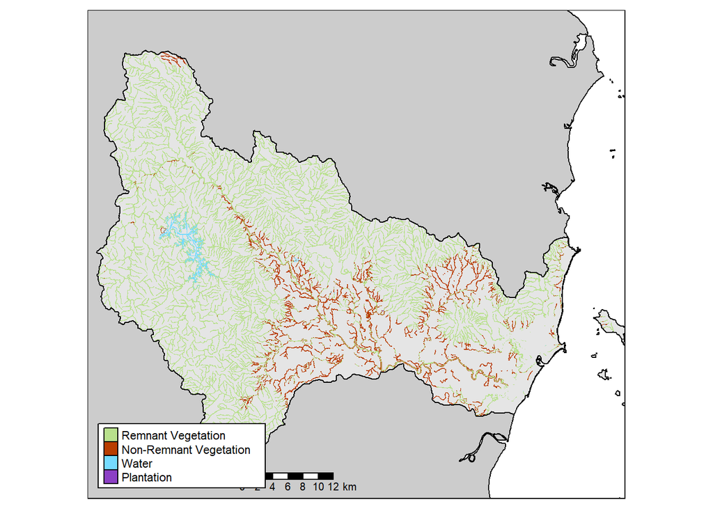

```r
map
```

## 5.4 Vegetation Over Time

Lastly we want to look at how the total amount of vegetation has changed over time. We will be using the percent change column in the table version to explore this.

Note, to make these plots more relevant we will not include the pre_clear or 1997 years because the change between these two is so huge it overshadows all other changes.

```r
#drop pre clear and 1997
re_rip_tbl_data_filtered <- re_rip_tbl_data |>
  filter(!year %in% c("pre_clear", "remnant_1997"))

#generate a list of potential years greater than the target data year
removal_years <- glue("remnant_{data_year+1:15}")

#remove data years that occured after the target data year
re_rip_tbl_data_filtered <- re_rip_tbl_data_filtered |>
  filter(!year %in% removal_years)

for (i in unique(re_rip_tbl_data_filtered$environment)){
  for (j in unique(n3_region$region)){

    #select the target area
    target_region_general <- re_rip_tbl_data_filtered |>
      filter(environment == i, region == j)

    #create region specific numbers
    target_region <- target_region_general |>
      select(region, year, vegetation, area) |>
      group_by(region, year, vegetation) |>
      summarise(area = sum(area)) |>
      ungroup() |>
      group_by(region, vegetation) |>
      arrange(vegetation, region, year) |>
      mutate(y_on_y_veg_area_change = area - lag(area),
             y_on_y_veg_percent_change = (y_on_y_veg_area_change/lag(area))*100,
             across(matches("percent"), \(x) as.vector(x)),
             across(matches("percent"), \(x) replace_na(x, 0)),
             across(matches("area"), \(x) replace_na(x, replace_value)),
             across(where(is.numeric), \(x) round(x, 5))) |>
      ungroup()

    #fix up erraneous percent change values (anything over 100% change gets a score of 100)
    target_region <- target_region |>
      mutate(y_on_y_veg_percent_change = case_when(abs(y_on_y_veg_percent_change) > 100 ~ 100,
                                                   T ~ y_on_y_veg_percent_change))

    #divide percent by 100 to correct for unit addition under 'scale_x_continuous() and order years
    target_region_ordered <- target_region |>
      mutate(y_on_y_veg_percent_change = y_on_y_veg_percent_change/100,
             year = str_remove_all(year, "remnant_"))

    #reorder years
    target_region_ordered <- target_region_ordered |>
      mutate(year = factor(year, levels = unique(target_region_ordered$year)))

    #plot
    plot <- ggplot(target_region_ordered, aes(y_on_y_veg_percent_change, year, fill = vegetation)) +
      geom_bar(stat = "identity", position = "dodge") +
      scale_y_discrete(limits = rev) +
      scale_fill_manual(values = my_tbl_palette) +
      scale_x_continuous(labels = scales::percent_format(accuracy = 0.1)) +
      theme(axis.text.x = element_text(colour = "black"),
            axis.line.x = element_line(colour = "black"),
            axis.text.y = element_text(colour = "black"),
            axis.line.y = element_line(colour = "black"),
            axis.ticks.y = element_blank(),
            panel.background = element_blank()) +
      geom_vline(xintercept = 0) +
      geom_hline(yintercept = seq(1.5, length(unique(target_region_ordered$year))-0.5, 1),
                 lwd = 0.5, colour = "grey80") +
      labs(x = "Year on Year Change (%)", y = "Year", fill = glue("{j} {i}\nRiparian Vegetation"))

    #edit names
    ij <- str_replace_all(paste(str_to_lower(i), str_to_lower(j), sep = "_"), " ", "_")

    #save
    ggsave(glue("{save_path}/plots/{ij}_region_riparian-vegetation_change-over-time.png"), plot)

    for (k in unique(target_region_general$basin)){

    #select the target area
    target_basin <- target_region_general |>
      filter(environment == i, basin == k)

    #divide percent by 100 to correct for unit addition under 'scale_x_continuous(), change year to factor for ordering
    target_basin_ordered <- target_basin |>
      group_by(basin, year, vegetation) |>
      summarise(y_on_y_veg_percent_change = sum(y_on_y_veg_percent_change)) |>
      mutate(y_on_y_veg_percent_change = y_on_y_veg_percent_change/100) |>
      mutate(year = str_remove_all(year, "remnant_"))

    #reorder years
    target_basin_ordered <- target_basin_ordered |>
      mutate(year = factor(year, levels = unique(target_basin_ordered$year)))

    #plot
    plot <- ggplot(target_basin_ordered, aes(y_on_y_veg_percent_change, year, fill = vegetation)) +
      geom_bar(stat = "identity", position = "dodge") +
      scale_y_discrete(limits = rev) +
      scale_fill_manual(values = my_tbl_palette) +
      scale_x_continuous(labels = scales::percent_format(accuracy = 0.1)) +
      theme(axis.text.x = element_text(colour = "black"),
            axis.line.x = element_line(colour = "black"),
            axis.text.y = element_text(colour = "black"),
            axis.line.y = element_line(colour = "black"),
            axis.ticks.y = element_blank(),
            panel.background = element_blank()) +
      geom_vline(xintercept = 0) +
      geom_hline(yintercept = seq(1.5, length(unique(target_basin_ordered$year))-0.5, 1),
                 lwd = 0.5, colour = "grey80") +
      labs(x = "Year on Year Change (%)", y = "Year", fill = glue("{k} {i}\nRiparian Vegetation"))

    #edit names
    ik <- str_replace_all(paste(str_to_lower(i), str_to_lower(k), sep = "_"), " ", "_")

    #save
    ggsave(glue("{save_path}/plots/{ik}_basin_riparian-vegetation_change-over-time.png"), plot)

    }
  }
}
```

Here is an example of how one of the change over time plots looks, noting that the actual outputted version looks much nicer.

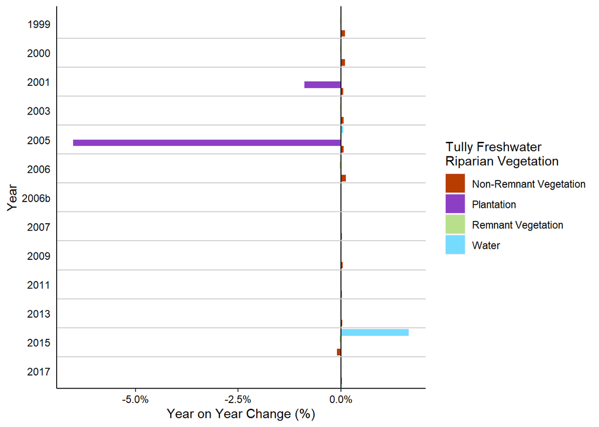

```r
plot
```

And that rounds out the script. Spicy.

# 6 Session Info

Below is the session info at the time of rendering this script. Of greatest importance is to note the R version, and the “other attached packages” as these are the most significant drivers of success/failure. It is also good to check the “attached base packages” and “loaded via a namespace” packages as well. To check your session info use `sessionInfo()`.

[session information not shown]

## Footnotes

[^1]: As of [issue 65](https://github.com/Northern-3/spatial-analyses/issues/65) the n3_habitat_data.R function is/has been retired and is now built into each habitat script independently.